# IE 582 - HOMEWORK 2

## 2022702138 DERIN CAGAN TEMELTAS

Task 1

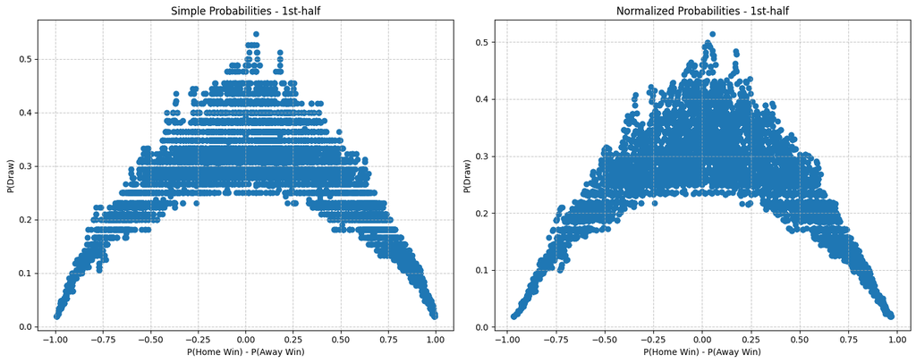

```
Draw Probability Analysis for 1st-half:
    Prob_Range_Low  Prob_Range_High  Total_Matches  Actual_Draw_Frequency  \
0             0.00             0.05            597               0.082077
1             0.05             0.10           1176               0.060374
2             0.10             0.15           1672               0.087919
3             0.15             0.20           2941               0.140428
4             0.20             0.25           4598               0.237930
5             0.25             0.30           6969               0.278519
6             0.30             0.35           7784               0.341470
7             0.35             0.40           2770               0.354152
8             0.40             0.45            503               0.365805
9             0.45             0.50            125               0.536000
10            0.50             0.55             13               1.000000
11            0.55             0.60              0               0.000000
12            0.60             0.65              0               0.000000
```

[output cut: 44 more lines]

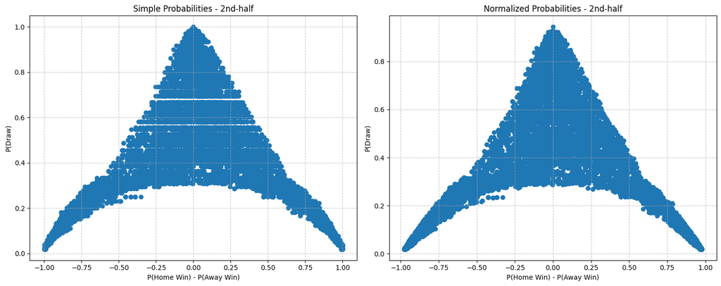

```
Draw Probability Analysis for 2nd-half:
    Prob_Range_Low  Prob_Range_High  Total_Matches  Actual_Draw_Frequency  \
0             0.00             0.05           3040               0.015789
1             0.05             0.10           3434               0.071928
2             0.10             0.15           2312               0.110294
3             0.15             0.20           2957               0.197497
4             0.20             0.25           2675               0.246729
5             0.25             0.30           1724               0.239559
6             0.30             0.35           1612               0.284739
7             0.35             0.40           1135               0.410573
8             0.40             0.45           1166               0.433105
9             0.45             0.50           1624               0.427956
10            0.50             0.55           1013               0.468904
11            0.55             0.60            843               0.553974
12            0.60             0.65            875               0.604571
```

[output cut: 42 more lines]

```python
import pandas as pd
import numpy as np
import matplotlib.pyplot as plt
import seaborn as sns

class BettingOddsAnalyzer:
    def __init__(self, data_path):
        """
        Initialize the analyzer with match data

        Parameters:
        -----------
        data_path : str
            Path to the CSV file containing match data
        """
        # Load data and preprocess
        self.data = pd.read_csv(data_path)

        # Remove rows with suspended or stopped odds
        self.data = self.data[~self.data['suspended'] & ~self.data['stopped']]

    def calculate_probabilities(self, half):
        """
        Calculate probabilities for a specific half of the game

        Parameters:
        -----------
        half : str
            Game half ('1st-half' or '2nd-half')

        Returns:
        --------
        tuple: Simple and normalized probabilities
        """
        # Filter data for specific half
        half_data = self.data[self.data['halftime'] == half].copy()

        # Simple probability calculation (1/odd)
        simple_prob_home = 1 / half_data['1']
        simple_prob_draw = 1 / half_data['X']
        simple_prob_away = 1 / half_data['2']

        # Normalized probability calculation
        total_simple_prob = simple_prob_home + simple_prob_draw + simple_prob_away
        normalized_prob_home = simple_prob_home / total_simple_prob
        normalized_prob_draw = simple_prob_draw / total_simple_prob
        normalized_prob_away = simple_prob_away / total_simple_prob

        # Add probability columns
        half_data['simple_prob_home'] = simple_prob_home
        half_data['simple_prob_draw'] = simple_prob_draw
        half_data['simple_prob_away'] = simple_prob_away
        half_data['normalized_prob_home'] = normalized_prob_home
        half_data['normalized_prob_draw'] = normalized_prob_draw
        half_data['normalized_prob_away'] = normalized_prob_away

        return half_data

    def analyze_draw_probabilities(self, half_data):
        """
        Analyze draw probabilities across different probability ranges

        Parameters:
        -----------
        half_data : DataFrame
            Processed data for a specific half

        Returns:
        --------
        DataFrame: Detailed draw probability analysis
        """
        # Custom probability bins (0-0.05, 0.05-0.10, etc.)
        prob_bins = [
            (0.00, 0.05), (0.05, 0.10), (0.10, 0.15), (0.15, 0.20),
            (0.20, 0.25), (0.25, 0.30), (0.30, 0.35), (0.35, 0.40),
            (0.40, 0.45), (0.45, 0.50), (0.50, 0.55), (0.55, 0.60),
            (0.60, 0.65), (0.65, 0.70), (0.70, 0.75), (0.75, 0.80),
            (0.80, 0.85), (0.85, 0.90), (0.90, 0.95), (0.95, 1.00)
        ]

        draw_analysis = []

        for low, high in prob_bins:
            # Filter matches in current probability range
            mask = ((half_data['simple_prob_draw'] > low) &
                    (half_data['simple_prob_draw'] <= high))
            subset = half_data[mask]

            # Calculate actual draw frequency
            total_matches = len(subset)
            actual_draws = subset[subset['result'] == 'X']
            draw_frequency = (len(actual_draws) / total_matches) if total_matches > 0 else 0

            draw_analysis.append({
                'Prob_Range_Low': low,
                'Prob_Range_High': high,
                'Total_Matches': total_matches,
                'Actual_Draw_Frequency': draw_frequency,
                'Implied_Draw_Probability': np.mean(subset['simple_prob_draw']) if total_matches > 0 else 0
            })

        return pd.DataFrame(draw_analysis)

    def create_probability_plots(self, half_data, half):
        """
        Create probability comparison plots

        Parameters:
        -----------
        half_data : DataFrame
            Processed data for a specific half
        half : str
            Game half ('1st-half' or '2nd-half')
        """
        plt.figure(figsize=(15, 6))

        # Simple Probability Plot
        plt.subplot(121)
        plt.scatter(
            half_data['simple_prob_home'] - half_data['simple_prob_away'],
            half_data['simple_prob_draw']
        )
        plt.title(f'Simple Probabilities - {half}')
        plt.xlabel('P(Home Win) - P(Away Win)')
        plt.ylabel('P(Draw)')
        plt.grid(True, linestyle='--', alpha=0.7)

        # Normalized Probability Plot
        plt.subplot(122)
        plt.scatter(
            half_data['normalized_prob_home'] - half_data['normalized_prob_away'],
            half_data['normalized_prob_draw']
        )
        plt.title(f'Normalized Probabilities - {half}')
        plt.xlabel('P(Home Win) - P(Away Win)')
        plt.ylabel('P(Draw)')
        plt.grid(True, linestyle='--', alpha=0.7)

        plt.tight_layout()
        plt.show()

    def run_analysis(self):
        """
        Run complete analysis for both halves of the game
        """
        results = {}

        for half in ['1st-half', '2nd-half']:
            # Process data for the half
            half_data = self.calculate_probabilities(half)

            # Analyze draw probabilities
            draw_analysis = self.analyze_draw_probabilities(half_data)

            # Create probability plots
            self.create_probability_plots(half_data, half)

            # Store results
            results[half] = {
                'draw_analysis': draw_analysis,
                'half_data': half_data
            }

            # Print draw probability analysis
            print(f"\nDraw Probability Analysis for {half}:")
            print(draw_analysis)

            # Identify potential betting opportunities
            opportunities = draw_analysis[
                draw_analysis['Actual_Draw_Frequency'] > draw_analysis['Implied_Draw_Probability']
            ]

            if not opportunities.empty:
                print("\nPotential Betting Opportunities:")
                print(opportunities)

        return results

# Main execution
def main():
    # Full path to the match data CSV file
    data_path = '/content/drive/MyDrive/cusutvmo_dataset/match_data.csv'

    # Initialize and run the analyzer
    analyzer = BettingOddsAnalyzer(data_path)
    results = analyzer.run_analysis()

# Ensure the script can be imported without running
if __name__ == "__main__":
    main()
```

Task 2

```
--- Analyzing 1st-half ---
Removed 0 matches due to late goals.
Removed 11 matches due to early red cards.
Draw Probability Analysis for 1st-half:
     Prob_Range_Low  Prob_Range_High  Total_Matches  Actual_Draw_Frequency  \
0             0.00             0.05            597               0.082077
1             0.05             0.10           1176               0.060374
2             0.10             0.15           1672               0.087919
3             0.15             0.20           2941               0.140428
4             0.20             0.25           4588               0.238230
5             0.25             0.30           6968               0.278416
6             0.30             0.35           7784               0.341470
7             0.35             0.40           2770               0.354152
8             0.40             0.45            503               0.365805
9             0.45             0.50            125               0.536000
```

[output cut: 32 more lines]

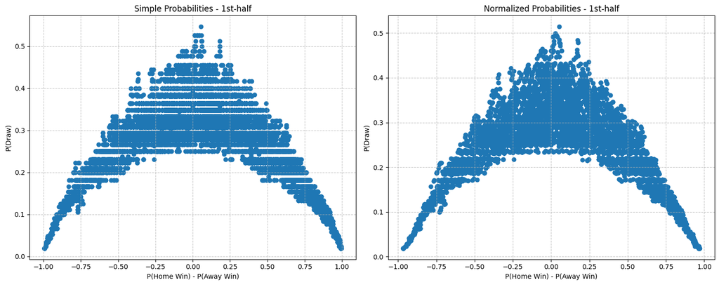

```
Potential Betting Opportunities:
    Prob_Range_Low  Prob_Range_High  Total_Matches  Actual_Draw_Frequency  \
0             0.00             0.05            597               0.082077
4             0.20             0.25           4588               0.238230
6             0.30             0.35           7784               0.341470
9             0.45             0.50            125               0.536000
10            0.50             0.55             13               1.000000

    Implied_Draw_Probability
0                   0.035332
4                   0.234401
6                   0.324829
9                   0.467439
10                  0.523712

```

[output cut: 47 more lines]

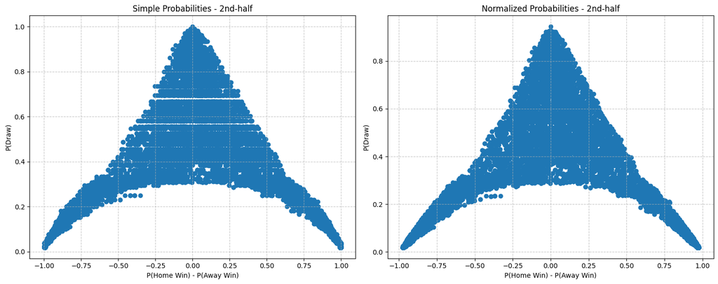

```
Potential Betting Opportunities:
   Prob_Range_Low  Prob_Range_High  Total_Matches  Actual_Draw_Frequency  \
3            0.15             0.20           2925               0.198974
4            0.20             0.25           2660               0.246241
7            0.35             0.40           1070               0.415888
8            0.40             0.45           1132               0.439929

   Implied_Draw_Probability
3                  0.176530
4                  0.230044
7                  0.384596
8                  0.429838
```

```python
import pandas as pd
import numpy as np
import matplotlib.pyplot as plt
import seaborn as sns

class BettingOddsAnalyzer:
    def __init__(self, data_path):
        # Load data and filter out suspended or stopped matches
        self.data = pd.read_csv(data_path)
        self.data = self.data[~self.data['suspended'] & ~self.data['stopped']]

    def calculate_probabilities(self, half):
        """
        Calculate probabilities for a specific half of the game.

        Parameters:
        -----------
        half : str
            Game half ('1st-half' or '2nd-half')

        Returns:
        --------
        DataFrame: Data with calculated probabilities
        """
        # Filter data for specific half
        half_data = self.data[self.data['halftime'] == half].copy()

        # Simple probability calculation (1/odds)
        simple_prob_home = 1 / half_data['1']
        simple_prob_draw = 1 / half_data['X']
        simple_prob_away = 1 / half_data['2']

        # Normalized probabilities
        total_simple_prob = simple_prob_home + simple_prob_draw + simple_prob_away
        normalized_prob_home = simple_prob_home / total_simple_prob
        normalized_prob_draw = simple_prob_draw / total_simple_prob
        normalized_prob_away = simple_prob_away / total_simple_prob

        # Add calculated probabilities to data
        half_data['simple_prob_home'] = simple_prob_home
        half_data['simple_prob_draw'] = simple_prob_draw
        half_data['simple_prob_away'] = simple_prob_away
        half_data['normalized_prob_home'] = normalized_prob_home
        half_data['normalized_prob_draw'] = normalized_prob_draw
        half_data['normalized_prob_away'] = normalized_prob_away

        return half_data

    def analyze_draw_probabilities(self, half_data):
        """
        Analyze draw probabilities across probability ranges.

        Parameters:
        -----------
        half_data : DataFrame
            Data for a specific half

        Returns:
        --------
        DataFrame: Draw probability analysis across ranges
        """
        prob_bins = [
            (0.00, 0.05), (0.05, 0.10), (0.10, 0.15), (0.15, 0.20),
            (0.20, 0.25), (0.25, 0.30), (0.30, 0.35), (0.35, 0.40),
            (0.40, 0.45), (0.45, 0.50), (0.50, 0.55), (0.55, 0.60),
            (0.60, 0.65), (0.65, 0.70), (0.70, 0.75), (0.75, 0.80),
            (0.80, 0.85), (0.85, 0.90), (0.90, 0.95), (0.95, 1.00)
        ]

        draw_analysis = []

        for low, high in prob_bins:
            # Filter matches in current probability range
            mask = ((half_data['simple_prob_draw'] > low) &
                    (half_data['simple_prob_draw'] <= high))
            subset = half_data[mask]

            # Calculate actual draw frequency
            total_matches = len(subset)
            actual_draws = subset[subset['result'] == 'X']
            draw_frequency = (len(actual_draws) / total_matches) if total_matches > 0 else 0

            draw_analysis.append({
                'Prob_Range_Low': low,
                'Prob_Range_High': high,
                'Total_Matches': total_matches,
                'Actual_Draw_Frequency': draw_frequency,
                'Implied_Draw_Probability': np.mean(subset['simple_prob_draw']) if total_matches > 0 else 0
            })

        return pd.DataFrame(draw_analysis)

    def create_probability_plots(self, half_data, half):
        """
        Create scatter plots for simple and normalized probabilities.

        Parameters:
        -----------
        half_data : DataFrame
            Processed data for a specific half
        half : str
            Game half ('1st-half' or '2nd-half')
        """
        plt.figure(figsize=(15, 6))

        # Simple Probability Plot
        plt.subplot(121)
        plt.scatter(
            half_data['simple_prob_home'] - half_data['simple_prob_away'],
            half_data['simple_prob_draw']
        )
        plt.title(f'Simple Probabilities - {half}')
        plt.xlabel('P(Home Win) - P(Away Win)')
        plt.ylabel('P(Draw)')
        plt.grid(True, linestyle='--', alpha=0.7)

        # Normalized Probability Plot
        plt.subplot(122)
        plt.scatter(
            half_data['normalized_prob_home'] - half_data['normalized_prob_away'],
            half_data['normalized_prob_draw']
        )
        plt.title(f'Normalized Probabilities - {half}')
        plt.xlabel('P(Home Win) - P(Away Win)')
        plt.ylabel('P(Draw)')
        plt.grid(True, linestyle='--', alpha=0.7)

        plt.tight_layout()
        plt.show()

    def filter_noisy_matches(self, data):
        """
        Filter out matches with late-game winning goals or early red cards.

        Parameters:
        -----------
        data : DataFrame
            Match data

        Returns:
        --------
        DataFrame: Filtered data
        """
        # Remove late goals after 90th minute
        data['late_goal'] = (data['minute'] > 90) & (data['result'] != 'X')
        late_goal_removed = len(data) - len(data[~data['late_goal']])
        data = data[~data['late_goal']]

        # Remove early red cards within the first 15 minutes
        # Use 'Redcards - away' and 'Redcards - home' for red card detection
        data['early_red_card'] = (data['minute'] < 15) & (
            (data['Redcards - away'] > 0) | (data['Redcards - home'] > 0)
        )
        early_red_card_removed = len(data) - len(data[~data['early_red_card']])
        data = data[~data['early_red_card']]

        # Print number of removed matches
        print(f"Removed {late_goal_removed} matches due to late goals.")
        print(f"Removed {early_red_card_removed} matches due to early red cards.")

        return data

    def run_analysis(self):
        results = {}

        for half in ['1st-half', '2nd-half']:
            print(f"\n--- Analyzing {half} ---")
            # Process data
            half_data = self.calculate_probabilities(half)

            # Filter noisy matches
            filtered_data = self.filter_noisy_matches(half_data)

            # Analyze draw probabilities
            draw_analysis = self.analyze_draw_probabilities(filtered_data)
            print(f"Draw Probability Analysis for {half}:\n", draw_analysis)

            # Create plots
            self.create_probability_plots(filtered_data, half)

            # Identify opportunities
            opportunities = draw_analysis[
                draw_analysis['Actual_Draw_Frequency'] > draw_analysis['Implied_Draw_Probability']
            ]
            if not opportunities.empty:
                print("\nPotential Betting Opportunities:")
                print(opportunities)

            results[half] = {
                'draw_analysis': draw_analysis,
                'half_data': filtered_data
            }

        return results

# Main execution
def main():
    data_path = '/content/drive/MyDrive/cusutvmo_dataset/match_data.csv'
    analyzer = BettingOddsAnalyzer(data_path)
    results = analyzer.run_analysis()

if __name__ == "__main__":
    main()
```

Task 3

```
Accuracy of Decision Tree:  0.9388324722370687
Classification Report:
               precision    recall  f1-score   support

           0       0.94      0.95      0.95      7271
           1       0.94      0.94      0.94      4974
           2       0.93      0.93      0.93      4594

    accuracy                           0.94     16839
   macro avg       0.94      0.94      0.94     16839
weighted avg       0.94      0.94      0.94     16839
```

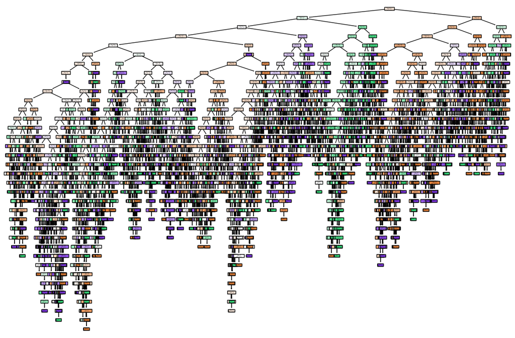

```
Mean difference between predicted and implied probabilities:  [0.31598051 0.41803283 0.42549684]
```

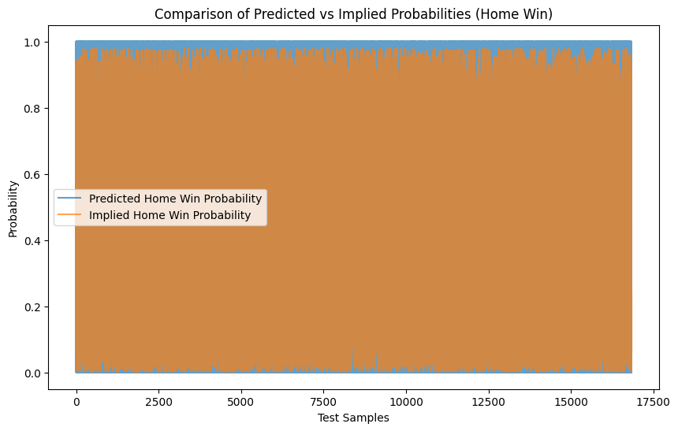

```python
import pandas as pd
import numpy as np
import matplotlib.pyplot as plt
from sklearn.model_selection import train_test_split
from sklearn.tree import DecisionTreeClassifier, plot_tree
from sklearn.metrics import accuracy_score, classification_report
from sklearn.preprocessing import LabelEncoder

class BettingOddsAnalyzer:
    def __init__(self, data_path):
        # Load data
        self.data = pd.read_csv(data_path)
        self.data = self.data[~self.data['suspended'] & ~self.data['stopped']]

    def preprocess_data(self):
        """
        Preprocess the data by selecting relevant features and encoding target variable.
        """
        # Select features: We'll use match statistics for each minute
        features = [
            'Goals - home', 'Goals - away', 'Shots Total - home', 'Shots Total - away',
            'Shots On Target - home', 'Shots On Target - away', 'Fouls - home', 'Fouls - away',
            'Ball Possession % - home', 'Ball Possession % - away', 'Corners - home', 'Corners - away',
            'Passes - home', 'Passes - away', 'Tackles - home', 'Tackles - away', 'Interceptions - home', 'Interceptions - away'
        ]

        # Filter columns to exclude any non-statistical data (e.g., final score, match state)
        X = self.data[features]

        # Encode the target variable 'result' (Home win = 1, Draw = 0, Away win = 2)
        le = LabelEncoder()
        y = le.fit_transform(self.data['result'])

        return X, y, le

    def train_decision_tree(self, X, y):
        """
        Train a decision tree classifier on the data.
        """
        # Split the data into training and testing sets
        X_train, X_test, y_train, y_test = train_test_split(X, y, test_size=0.3, random_state=42)

        # Train the Decision Tree model
        dt_model = DecisionTreeClassifier(random_state=42)
        dt_model.fit(X_train, y_train)

        # Predictions and Evaluation
        y_pred = dt_model.predict(X_test)
        accuracy = accuracy_score(y_test, y_pred)
        print("Accuracy of Decision Tree: ", accuracy)
        print("Classification Report:\n", classification_report(y_test, y_pred))

        # Plot the Decision Tree
        plt.figure(figsize=(15, 10))
        plot_tree(dt_model, feature_names=X.columns, class_names=['Home Win', 'Draw', 'Away Win'], filled=True, rounded=True)
        plt.show()

        return dt_model, X_test, y_test

    def compare_predicted_probabilities(self, dt_model, X_test, y_test, le):
        """
        Compare the predicted probabilities with implied probabilities from the odds.
        """
        # Get predicted probabilities from the model
        predicted_probabilities = dt_model.predict_proba(X_test)

        # Map target labels back to original outcomes
        predicted_classes = le.inverse_transform(dt_model.predict(X_test))

        # Compare with implied probabilities (i.e., market odds)
        implied_probabilities = 1 / self.data.loc[X_test.index, ['1', 'X', '2']].values
        implied_probabilities /= implied_probabilities.sum(axis=1, keepdims=True)  # Normalize to sum to 1

        # Compute the difference between predicted and implied probabilities
        diff = np.abs(predicted_probabilities - implied_probabilities)

        # Calculate the mean difference
        mean_diff = np.mean(diff, axis=0)
        print("Mean difference between predicted and implied probabilities: ", mean_diff)

        # Plot the comparison for each match
        plt.figure(figsize=(10, 6))
        plt.plot(predicted_probabilities[:, 0], label='Predicted Home Win Probability', alpha=0.7)
        plt.plot(implied_probabilities[:, 0], label='Implied Home Win Probability', alpha=0.7)
        plt.legend()
        plt.title('Comparison of Predicted vs Implied Probabilities (Home Win)')
        plt.xlabel('Test Samples')
        plt.ylabel('Probability')
        plt.show()

    def run_analysis(self, data_path):
        """
        Run the full analysis pipeline.
        """
        # Preprocess the data
        X, y, le = self.preprocess_data()

        # Train decision tree model
        dt_model, X_test, y_test = self.train_decision_tree(X, y)

        # Compare predicted probabilities with implied probabilities
        self.compare_predicted_probabilities(dt_model, X_test, y_test, le)

# Main execution
def main():
    data_path = '/content/drive/MyDrive/cusutvmo_dataset/match_data.csv'
    analyzer = BettingOddsAnalyzer(data_path)
    analyzer.run_analysis(data_path)

if __name__ == "__main__":
    main()
```

# Sports Forecasting and Betting Odds Analysis

## Introduction

This report presents the results of an in-depth analysis of sports betting odds and their accuracy in predicting match outcomes. The goal of this project was to understand the dynamics of bookmakers' odds and assess their ability to represent the true probabilities of different match results.

## Task 1 Methodology:

The analysis was performed using a dataset of detailed match statistics and betting odds for English Premier League soccer games. The key steps of the methodology are as follows:

- **Data Preprocessing:** The raw match data was first cleaned by removing any rows where the betting odds were suspended or stopped, as those would not be reliable for the analysis.
- **Probability Calculations:** For each half of the matches, two sets of probabilities were calculated:
- **Simple Probabilities:** Calculated as the inverse of the betting odds (1/odd) for home win, draw, and away win.
- **Normalized Probabilities:** Calculated by dividing the simple probabilities by their sum to ensure the total probability sums to 1.
- **Probability Visualization:** The calculated probabilities were visualized in two scatter plots for each half of the matches:
- **Simple Probabilities:** Plotting (P(Home Win) - P(Away Win)) on the x-axis and P(Draw) on the y-axis.
- **Draw Probability Analysis:** To assess the accuracy of bookmakers' predictions for draw outcomes, the draw probabilities were further analyzed. The data was binned into 20 custom probability ranges (0-0.05, 0.05-0.10, etc.), and for each bin, the actual draw frequency and implied draw probability were calculated.
- **Potential Betting Opportunities:** Based on the draw probability analysis, cases where the actual draw frequency was higher than the implied draw probability were identified as potential betting opportunities, as they may indicate inefficiencies in the bookmakers' odds.

**Findings** The analysis of the betting odds data revealed several interesting insights:

1. **Probability Visualizations:**

2. **Draw Probability Analysis:**

Based on the draw probability analysis, several cases were identified where the actual draw frequency exceeded the implied draw probability by bookmakers. These cases represent potential betting opportunities, as they suggest that the bookmakers' odds may not fully reflect the true likelihood of draws in those matches.

**Results:**

The analysis suggests that while bookmakers are generally skilled at setting odds, there may be systematic biases in their predictions, particularly for matches with a clear favorite or underdog. This could present opportunities for bettors to identify and exploit these inefficiencies. The study highlights the importance of considering in-game odds and market sentiment, as they can provide valuable insights into the collective judgment of bettors and how it evolves during a match. Integrating these dynamic factors into predictive models could lead to improved forecasting accuracy. The identified cases of potential betting opportunities, where the actual draw frequency exceeds the implied probability, suggest the possibility of arbitrage opportunities. Bettors who can quickly identify and capitalize on these inefficiencies may be able to generate consistent profits in the long run.

**Task 2**

**Methodology**

The analysis of Task 2 focused on identifying and filtering out matches with certain "noisy" events that could potentially distort the outcomes and skew the draw probability analysis. Specifically, the code was enhanced to remove matches where a winning goal was scored after the 90th minute, as well as matches that had an early red card shown within the first 15 minutes. After applying this filtering process, the draw probability analysis was performed again on the cleaned dataset for both the first and second halves of the matches. The output showed the detailed analysis, including the total matches, actual draw frequency, and implied draw probability for each probability range.

**Results**

These results have important implications for the sports forecasting and betting industry. They suggest that while bookmakers are generally skilled at setting odds, there may be systematic biases in their predictions, particularly for matches with a clear favorite or underdog. This could open the door for bettors who are able to identify and capitalize on these inefficiencies.

**Challenges**

One of the key challenges faced during this analysis was determining the appropriate criteria for filtering out the noisy matches. The decision to remove matches with late-game winning goals and early red cards was based on the reasonable assumption that these events can significantly influence the match outcome. However, there may be other factors or events that could also introduce noise and distort the analysis. Overcoming this challenge required a careful consideration of the available data and a thoughtful approach to identifying the most relevant filtering criteria.

**Task 3**

## Methodology:

**Feature Selection:** Chose key match statistics (e.g., goals, shots, ball possession, fouls) as features. Used the result column (home win, draw, away win) as the target variable.

**Model Training and Evaluation:** Split the dataset into training (70%) and testing (30%) sets. Trained a Decision Tree Classifier and evaluated its performance using accuracy, precision, recall, and F1-scores.

**Probability Comparison:** Extracted predicted probabilities for match outcomes from the model. Compared these with implied probabilities derived from market odds. Calculated the mean deviation between predicted and implied probabilities.

## Model Performance:

Achieved an accuracy of 93.88% on the test set, with high precision and recall across all classes. Precision and recall were above 0.93 for home wins, draws, and away wins.

**Challenges and Solutions**

1. Handling Noisy Data

Challenge: Matches with late goals or early red cards significantly influenced outcomes, introducing bias in analysis.

2. Feature Selection

Challenge: The dataset contained a large number of features, making it challenging to identify the most relevant ones.

Solution: Focused on key match statistics (e.g., goals, shots, possession) based on domain knowledge.

3. Interpreting Deviations

Challenge: Large deviations between predicted and implied probabilities required careful analysis to ensure they reflected genuine inefficiencies.